# Fundamentos de los modelos lineales (regresión)

PSI4035 Taller 01

dacarras

# Taller 1: Fundamentos de los de los modelos lineales

En esta sesión vamos a ilustrar empleando a R diferentes conceptos y operaciones introducidos por Vik (2014) en los capítulos 1 a 3.

Los conceptos que vamos a revisar son:

- variable dependiente o variable de respuesta
- variable independiente, covariable o variable predictora
- ecuación de un modelo de regresión
- suma de errores al cuadrado
- evaluar supuestos de un modelo de regresión
  - linealidad
  - homocedasticidad
  - normalida de los residuos

# Librerías en uso

- Para ejecutar el presente código, estamos empleando las siguientes librerias:
  - `library(dplyr)` para manipular datos
  - `library(knitr)` para mostrar las tablas como texto plano en consola
  - `library(ggplot2)` para construir gráficos con más opciones
  - `library(texreg)` para reordenar los output de varios de modelos de regresión
  - `library(broom)` para extraer tablas de los output de los modelos de regresión+
  - `library(lmtest)` para aplicar la prueba de Durbin Watson (correlación de residuales)

Para instalar estas librerias podemos ejecutar los siguientes códigos

```r
#------------------------------------------------------------------------------
# instalar librerias
#------------------------------------------------------------------------------

#----------------------------------------------------------
# librerias
#----------------------------------------------------------

install.packages('tidyverse') # incluye a dplyr y ggplot2
                              # junto a otras librerias útiles

install.packages('knitr')     # para mostrar tablas como texto plano

install.packages('texreg')    # para reordenar los output de varios
                              # de modelos de regresión

install.packages('broom')     # para extraer tablas de los output
                              # de los modelos de regresión

install.packages('lmtest')    # para evaluar la independencia
                              # de las residuales
```

# Modelo de regresión con un predictor (*bivariate regression*)

Vik (2014) plantea, que podemos plantearnos tres preguntas generales acerca de dos variables:

- Q1: estan relacionadas estas dos variables?
- Q2: cuál es la dirección de la relación?
- Q3: que tan grande es la relación entre estas variables?

Para abordar estas preguntas empleando R, primero vamos a cargar los datos de la tabla 3.2. Luego de haber cargado estados datos, vamos a visualizar los datos mediante un dispersiograma o *scatter plot*. Finalmente, vamos ajustar dos modelos de regressión: el modelo sin predictores (modelo nulo, o modelo compacto), y el modelo con predictores (modelo aumentado).

## Cargar datos Tabla 3.2

```r
#------------------------------------------------------------------------------
# datos
#------------------------------------------------------------------------------

#----------------------------------------------------------
# tabla 3.2
#----------------------------------------------------------

data_table_3_2 <- read.table(
text="
person  y x x_q xy
1 2 8 64  16
2 3 9 81  27
3 3 9 81  27
4 4 10  100 40
5 7 6 36  42
6 5 7 49  35
7 5 4 16  20
8 7 5 25  35
9 8 3 9 24
10  9 1 1 9
11  9 2 4 18
12  10  2 4 20

",
header=TRUE, stringsAsFactors = FALSE)

#--------------------------------------
# mostrar tabla
#--------------------------------------

knitr::kable(data_table_3_2)
```

| person | y | x | x_q | xy |
| --- | --- | --- | --- | --- |
| 1 | 2 | 8 | 64 | 16 |
| 2 | 3 | 9 | 81 | 27 |
| 3 | 3 | 9 | 81 | 27 |
| 4 | 4 | 10 | 100 | 40 |
| 5 | 7 | 6 | 36 | 42 |
| 6 | 5 | 7 | 49 | 35 |
| 7 | 5 | 4 | 16 | 20 |
| 8 | 7 | 5 | 25 | 35 |
| 9 | 8 | 3 | 9 | 24 |
| 10 | 9 | 1 | 1 | 9 |
| 11 | 9 | 2 | 4 | 18 |
| 12 | 10 | 2 | 4 | 20 |

## Scatter plot tabla 3.2

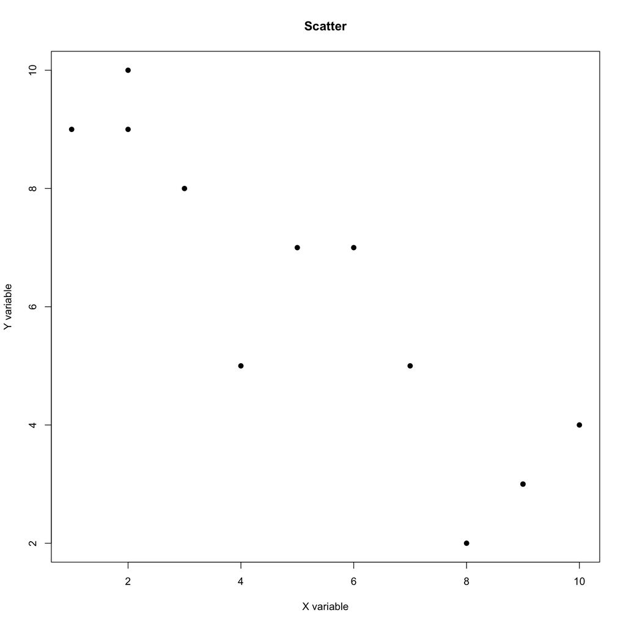

```r
#------------------------------------------------------------------------------
# scatter
#------------------------------------------------------------------------------

#--------------------------------------
# codigo base
#--------------------------------------

with(data_table_3_2,
  plot(
    x=x,
    y=y,
    xlab = "X variable",
    ylab = "Y variable",
    main = 'Scatter',
    pch = 19,
    frame = TRUE
    )
  )

#--------------------------------------
# codigo ggplot
#--------------------------------------

library(dplyr)
library(ggplot2)
```

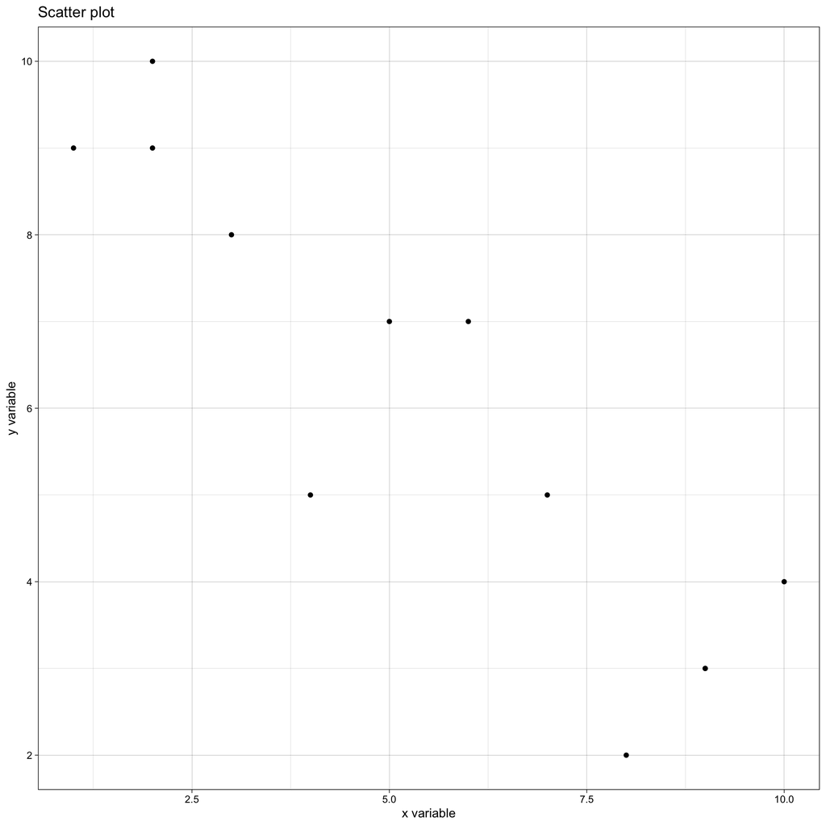

```r
data_table_3_2 %>%
ggplot(., aes(y = y, x = x)) +
geom_point(alpha = 1, col = 'black') +
xlab('x variable') +
ylab('y variable') +
ggtitle('Scatter plot') +
theme_linedraw()
```

## Ajustar modelo de regresión

- Los modelos de regressión que vamos a ajustar son los siguientes:
- Modelo Compacto o Modelo Nulo
  $$y_{i} = \beta_{0} + \epsilon_{i}$$
- Modelo Aumentado, de un solo predictor
  $$y_{i} = \beta_{0} + \beta_{1}*x_{i} + \epsilon_{i}$$
- Modelo Aumentado, con un predictor centrado a la gran media

$$y_{i} = \beta_{0} + \beta_{1}*(x_{i} - \bar{x}_{i}) + \epsilon_{i}$$

```r
#------------------------------------------------------------------------------
# ajustar modelos
#------------------------------------------------------------------------------

#--------------------------------------
# preparar datos codigo base
#--------------------------------------

data_model <- data_table_3_2[, c('y','x')]
data_model$x_cgm <- data_table_3_2$x - mean(data_table_3_2$x, na.rm = TRUE)


#--------------------------------------
# preparar datos (dplyr)
#--------------------------------------

data_model <- data_table_3_2 %>%
              mutate(x_g = mean(x, na.rm = TRUE)) %>%
              mutate(x_cgm = x - x_g) %>%
              dplyr::select(y, x, x_cgm) %>%
              dplyr::glimpse()
```

```
## Rows: 12
## Columns: 3
## $ y     <int> 2, 3, 3, 4, 7, 5, 5, 7, 8, 9, 9, 10
## $ x     <int> 8, 9, 9, 10, 6, 7, 4, 5, 3, 1, 2, 2
## $ x_cgm <dbl> 2.5, 3.5, 3.5, 4.5, 0.5, 1.5, -1.5, -0.5, -2.5, -4.5, -3.5, -3.5
```

```r
#--------------------------------------
# mostrar datos
#--------------------------------------

knitr::kable(data_model)
```

| y | x | x_cgm |
| --- | --- | --- |
| 2 | 8 | 2.5 |
| 3 | 9 | 3.5 |
| 3 | 9 | 3.5 |
| 4 | 10 | 4.5 |
| 7 | 6 | 0.5 |
| 5 | 7 | 1.5 |
| 5 | 4 | -1.5 |
| 7 | 5 | -0.5 |
| 8 | 3 | -2.5 |
| 9 | 1 | -4.5 |
| 9 | 2 | -3.5 |
| 10 | 2 | -3.5 |

```r
#--------------------------------------
# formulas
#--------------------------------------

f00 <- as.formula(y ~ + 1)
f01 <- as.formula(y ~ + 1 + x)
f02 <- as.formula(y ~ + 1 + x_cgm)

#--------------------------------------
# ajustar modelos
#--------------------------------------

m00 <- lm(f00, data = data_model)
m01 <- lm(f01, data = data_model)
m02 <- lm(f02, data = data_model)

#--------------------------------------
# comparar modelos de forma sintética
#--------------------------------------

texreg::screenreg(
    list(m00, m01, m02),
    star.symbol = "*",
    center = TRUE,
    doctype = FALSE,
    dcolumn = TRUE,
    booktabs = TRUE,
    single.row = FALSE
    )
```

```
##
## ============================================
##              Model 1    Model 2    Model 3
## --------------------------------------------
## (Intercept)   6.00 ***  10.27 ***   6.00 ***
##              (0.78)     (0.76)     (0.36)
## x                       -0.78 ***
##                         (0.12)
## x_cgm                              -0.78 ***
##                                    (0.12)
## --------------------------------------------
## R^2           0.00       0.80       0.80
## Adj. R^2      0.00       0.79       0.79
## Num. obs.    12         12         12
## ============================================
## *** p < 0.001; ** p < 0.01; * p < 0.05
```

```r
#--------------------------------------
# tamaño de efecto de la relación
#--------------------------------------

# como r de Pearson
with(data_model, cor(y, x))
```

```
## [1] -0.8971007
```

```r
# como R2
summary(m02)$r.squared
```

```
## [1] 0.8047897
```

```r
# R2 obtenido con library(broom)
broom::glance(m02)
```

```
## # A tibble: 1 × 12
##   r.squared adj.r.squared sigma statistic   p.value    df logLik   AIC   BIC
##       <dbl>         <dbl> <dbl>     <dbl>     <dbl> <dbl>  <dbl> <dbl> <dbl>
## 1     0.805         0.785  1.25      41.2 0.0000763     1  -18.6  43.2  44.7
## # … with 3 more variables: deviance <dbl>, df.residual <int>, nobs <int>
```

# Abordando las preguntas básicas de Vik

- Q1: estan relacionadas estas dos variables?
  - Sí, la variable `y` esta relacionada de forma lineal a la variable `x`.
- Q2: cuál es la dirección de la relación?
  - La forma de la relación es negativa.
  - A medida que aumentan los valores de `x`, esperamos que los valores `y` disminuyan.
- Q3: que tan grande es la relación entre estas variables?
  - La relación es grande. `x` e `y`, presentan una correlación alta ($r$ = -.89).
  - En términos de varianza explicada, `x` explica hasta un 80% de la varianza de `y` ($R^2$ = .80)

# Resultados

## Resultados del modelo nulo

```r
#------------------------------------------------------------------------------
# resultados
#------------------------------------------------------------------------------

#--------------------------------------
# coeficientes
#--------------------------------------

summary(m00)
```

```
##
## Call:
## lm(formula = f00, data = data_model)
##
## Residuals:
##    Min     1Q Median     3Q    Max
##  -4.00  -2.25   0.00   2.25   4.00
##
## Coefficients:
##             Estimate Std. Error t value  Pr(>|t|)
## (Intercept)   6.0000     0.7785   7.707 0.0000093 ***
## ---
## Signif. codes:  0 '***' 0.001 '**' 0.01 '*' 0.05 '.' 0.1 ' ' 1
##
## Residual standard error: 2.697 on 11 degrees of freedom
```

```r
#--------------------------------------
# análisis de varianza
#--------------------------------------

anova(m00)
```

```
## Analysis of Variance Table
##
## Response: y
##           Df Sum Sq Mean Sq F value Pr(>F)
## Residuals 11     80  7.2727
```

## Resultados del modelo con un predictor

```r
#------------------------------------------------------------------------------
# resultados
#------------------------------------------------------------------------------

#--------------------------------------
# coeficientes
#--------------------------------------

summary(m01)
```

```
##
## Call:
## lm(formula = f01, data = data_model)
##
## Residuals:
##     Min      1Q  Median      3Q     Max
## -2.1635 -0.3365  0.1121  0.7804  1.4907
##
## Coefficients:
##             Estimate Std. Error t value     Pr(>|t|)
## (Intercept)  10.2664     0.7561  13.579 0.0000000907 ***
## x            -0.7757     0.1208  -6.421 0.0000762671 ***
## ---
## Signif. codes:  0 '***' 0.001 '**' 0.01 '*' 0.05 '.' 0.1 ' ' 1
##
## Residual standard error: 1.25 on 10 degrees of freedom
## Multiple R-squared:  0.8048, Adjusted R-squared:  0.7853
## F-statistic: 41.23 on 1 and 10 DF,  p-value: 0.00007627
```

```r
#--------------------------------------
# análisis de varianza
#--------------------------------------

anova(m01)
```

```
## Analysis of Variance Table
##
## Response: y
##           Df Sum Sq Mean Sq F value     Pr(>F)
## x          1 64.383  64.383  41.227 0.00007627 ***
## Residuals 10 15.617   1.562
## ---
## Signif. codes:  0 '***' 0.001 '**' 0.01 '*' 0.05 '.' 0.1 ' ' 1
```

# Interpretación (modelo 1)

- Intercepto ($b_{0}$)
- Coeficiente de regresión (($b_{1}$))

## Intercepto y beta

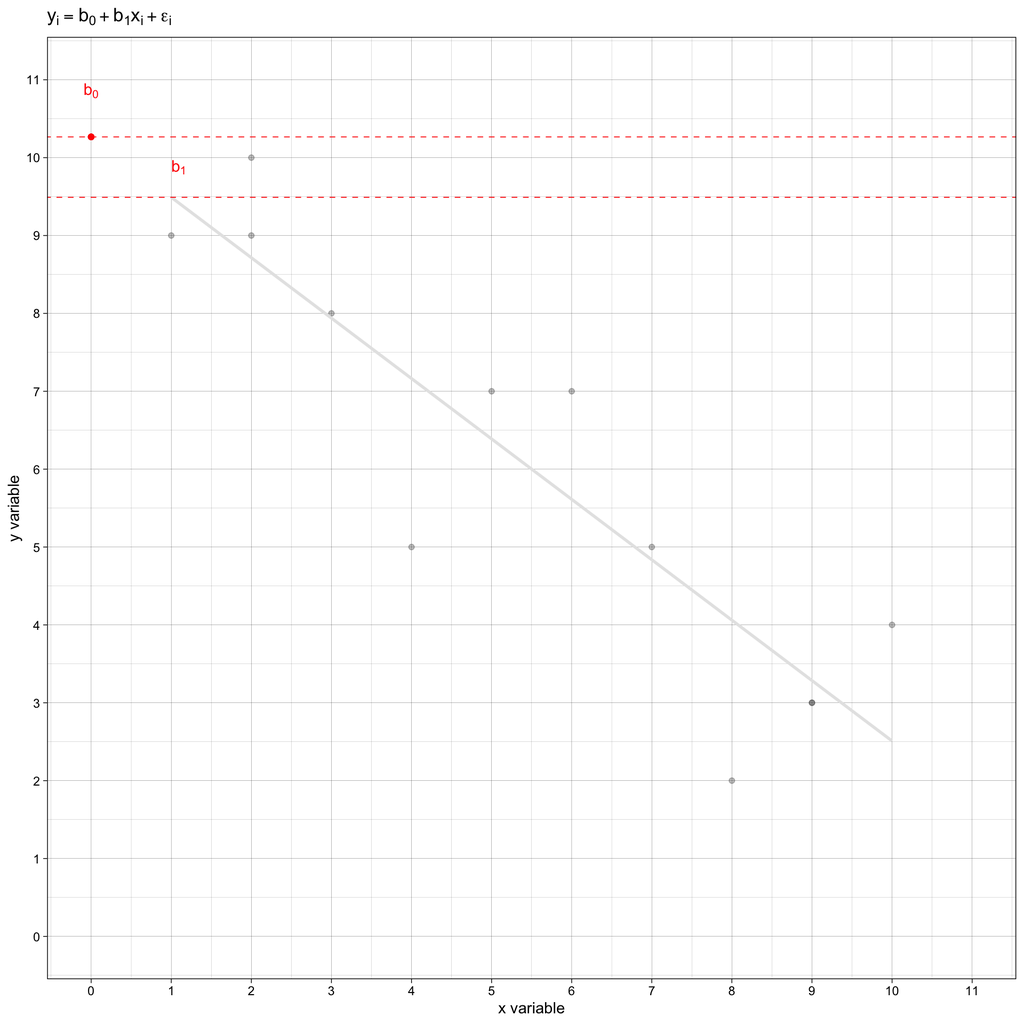

```r
#------------------------------------------------------------------------------
# proyección
#------------------------------------------------------------------------------

#----------------------------------------------------------
# intercepto
#----------------------------------------------------------

b00_m01 <- lm(y ~ + 1 + x, data = data_model) %>%
           broom::tidy() %>%
           dplyr::filter(term == '(Intercept)') %>%
           dplyr::select(estimate) %>%
           dplyr::pull()


b01_m01 <- lm(y ~ + 1 + x, data = data_model) %>%
           broom::tidy() %>%
           dplyr::filter(term == 'x') %>%
           dplyr::select(estimate) %>%
           dplyr::pull()

#----------------------------------------------------------
# agregar valores esperados (y_hat), a una base de datos
#----------------------------------------------------------

fitted_values <- lm(y ~ + 1 + x, data = data_model) %>%
                 predict()

data_plot_raw <- data_model %>%
                 mutate(y_hat = fitted_values)

#----------------------------------------------------------
# proyección de modelo sobre datos observados
#----------------------------------------------------------

data_plot_raw %>%
ggplot(., aes(y = y, x = x)) +
geom_point(alpha = .3, col = 'grey20') +
  geom_smooth(
    formula = y ~ x,
    method = "lm",
    se = FALSE,
    colour = "grey90",
    alpha = .005
    ) +
# intercepto
geom_point(aes(y = b00_m01, x = 0), col = 'red', alpha = .5) +
# itercepto
geom_abline(
  intercept = b00_m01,
  slope = 0,
  color="red",
  linetype="dashed",
  size= .3
  ) +
annotate('text',
  x =   0,
  y =  b00_m01 + .5,
  size = 4,
  vjust = 0,
  colour = 'red',
  label = paste0('b[0]'),
  parse = TRUE
  ) +
# beta 1
geom_abline(
  intercept = b00_m01 + b01_m01,
  slope = 0,
  color="red",
  linetype="dashed",
  size= .3
  ) +
annotate('text',
  x =  1,
  y =  b00_m01 + (b01_m01)/2,
  size = 4,
  hjust = 0,
  colour = 'red',
  label = paste0('b[01]'),
  parse = TRUE
  ) +
xlab('x variable') +
ylab('y variable') +
scale_x_continuous(breaks=seq(0,11,1), limits = c(0, 11)) +
scale_y_continuous(breaks=seq(0,11,1), limits = c(0, 11)) +
labs(
  title = expression(y[i] == b[0] + b[1] * x[i] + epsilon[i]),
  parse = TRUE
  ) +
theme_linedraw()
```

# Interpretacion del modelo reparametrizado (modelo 2)

El centrado de variable es útil para darle una interpretación sustantiva al intercepto del modelo ajustado.

- Intercepto ($b_{0}$), cuando $(x_{i} - \bar{x}_{i})$ es el predictor
- Coeficiente de regresión (($b_{1}$))

## Proyección de intercepto y beta

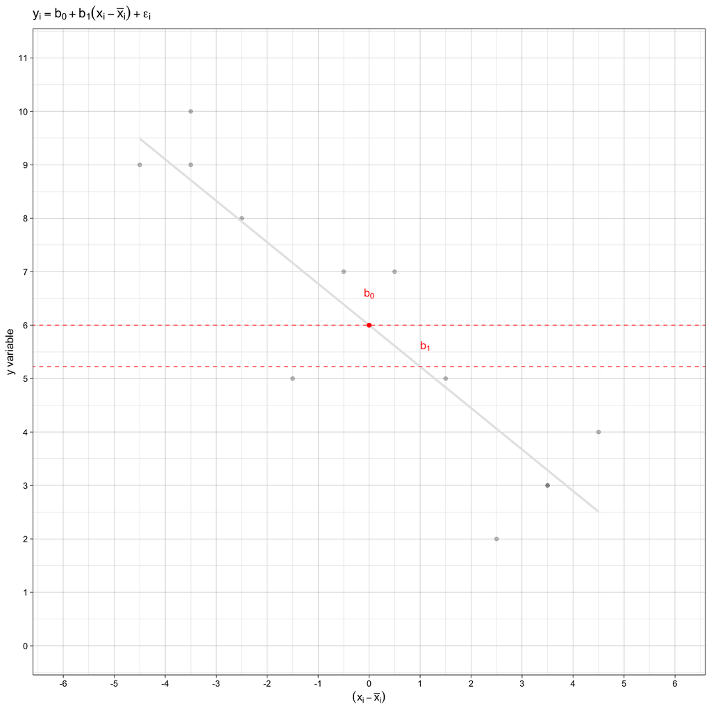

```r
#------------------------------------------------------------------------------
# proyección
#------------------------------------------------------------------------------

#----------------------------------------------------------
# intercepto
#----------------------------------------------------------


b00_m02 <- lm(y ~ + 1 + x_cgm, data = data_model) %>%
           broom::tidy() %>%
           dplyr::filter(term == '(Intercept)') %>%
           dplyr::select(estimate) %>%
           dplyr::pull()


b01_m02 <- lm(y ~ + 1 + x_cgm, data = data_model) %>%
           broom::tidy() %>%
           dplyr::filter(term == 'x_cgm') %>%
           dplyr::select(estimate) %>%
           dplyr::pull()

#----------------------------------------------------------
# agregar valores esperados (y_hat), a una base de datos
#----------------------------------------------------------

fitted_values <- lm(y ~ + 1 + x_cgm, data = data_model) %>%
                 predict()

data_plot_cen <- data_model %>%
                 mutate(y_hat = fitted_values)

#----------------------------------------------------------
# proyección de modelo sobre datos observados
#----------------------------------------------------------

data_plot_cen %>%
ggplot(., aes(y = y, x = x_cgm)) +
geom_point(alpha = .3, col = 'grey20') +
  geom_smooth(
    formula = y ~ x,
    method = "lm",
    se = FALSE,
    colour = "grey90",
    alpha = .005
    ) +
# punto del intercepto
geom_point(aes(y = b00_m02, x = 0), col = 'red', alpha = .5) +
# linea del intercepto
geom_abline(
  intercept = b00_m02,
  slope = 0,
  color="red",
  linetype="dashed",
  size= .3
  ) +
annotate('text',
  x =   0,
  y =  b00_m02 + .5,
  size = 4,
  vjust = 0,
  colour = 'red',
  label = paste0('b[0]'),
  parse = TRUE
  ) +
# beta 1
geom_abline(
  intercept = b00_m02 + b01_m02,
  slope = 0,
  color="red",
  linetype="dashed",
  size= .3
  ) +
annotate('text',
  x =  1,
  y =  b00_m02 + (b01_m02)/2,
  size = 4,
  hjust = 0,
  colour = 'red',
  label = paste0('b[1]'),
  parse = TRUE
  ) +
xlab(expression((x[i] - bar(x)[i]))) +
ylab('y variable') +
scale_y_continuous(breaks=seq(0,11,1), limits = c(0, 11)) +
scale_x_continuous(breaks=seq(-6,6,1), limits = c(-6, 6)) +
labs(
  title = expression(y[i] == b[0] + b[1] * (x[i] - bar(x)[i]) + epsilon[i]),
  parse = TRUE
  ) +
theme_linedraw()
```

## Interpretación de resultados

**Intercepto** ($b_{0}$)

- $b_{0}$ corresponde a la media de $y_{i}$, cuando $x_{i}$ es ingresado al modelo con sus valores centrados.
- Otra forma de interpretar este estimado, es que $b_{0}$ es el valor esperado de $y_{i}$, cuando $(x_{i} - \bar{x}_{i}) = 0$.
- En otras palabras, $b_{0}$ es el valor que esperamos de $y_{i}$, a valores promedio de $x_{i}$.

**Coeficiente** ($b_{1}$)

- $b_{1}$ corresponde al valor que esperamos que tome $y_{i}$, condicional al cambio de una unidad de $x_{i}$.
- Empleando los resultados del modelo ajustado (*m02*), esperamos que los casos donde $(x_{i} - \bar{x}_{i}) = 1$, obtengan $b_{0} + b_{1}$ valores en la escala de $y_{i}$.

# Visualización de errores

## Lollipop plot de Residuales

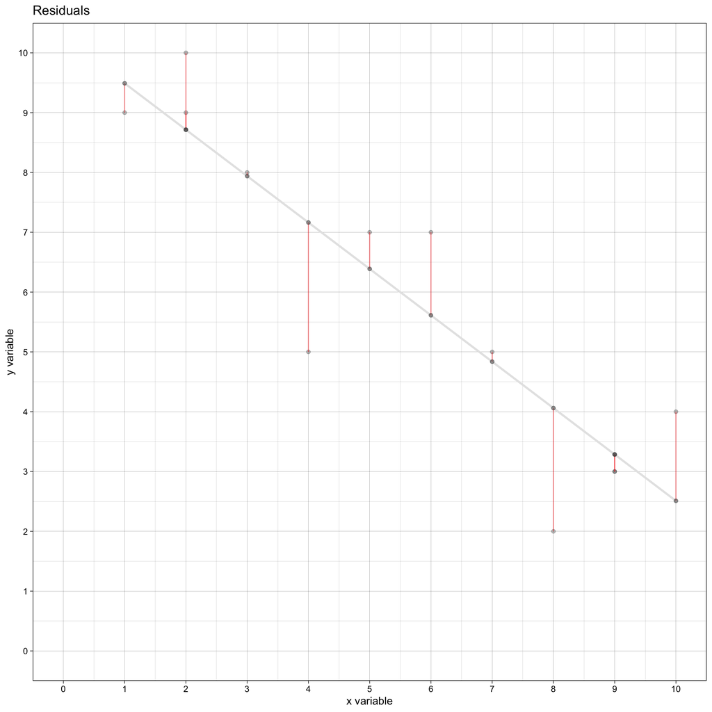

```r
#------------------------------------------------------------------------------
# residuales
#------------------------------------------------------------------------------

#----------------------------------------------------------
# crear valores esperados
#----------------------------------------------------------

fitted_values <- lm(y ~ + 1 + x, data = data_model) %>%
                 predict()

#----------------------------------------------------------
# agregar valores esperados (y_hat), a una base de datos
#----------------------------------------------------------

data_fitted <- data_model %>%
               mutate(y_hat = fitted_values)

#----------------------------------------------------------
# lollipop plot
#----------------------------------------------------------

data_fitted %>%
ggplot(., aes(y = y, x = x)) +
geom_point(alpha = .3, col = 'grey20') +
  geom_smooth(
    formula = y ~ x,
    method = "lm",
    se = FALSE,
    colour = "grey90",
    alpha = .005
    ) +
geom_segment(aes(xend = x, yend = y_hat), alpha = .4, col = 'red') +
geom_point(aes(y = y_hat), col = 'grey25', alpha = .5) +
xlab('x variable') +
ylab('y variable') +
scale_x_continuous(breaks=seq(0,10,1), limits = c(0, 10)) +
scale_y_continuous(breaks=seq(0,10,1), limits = c(0, 10)) +
ggtitle('Residuals') +
theme_linedraw()
```

## Squared errors

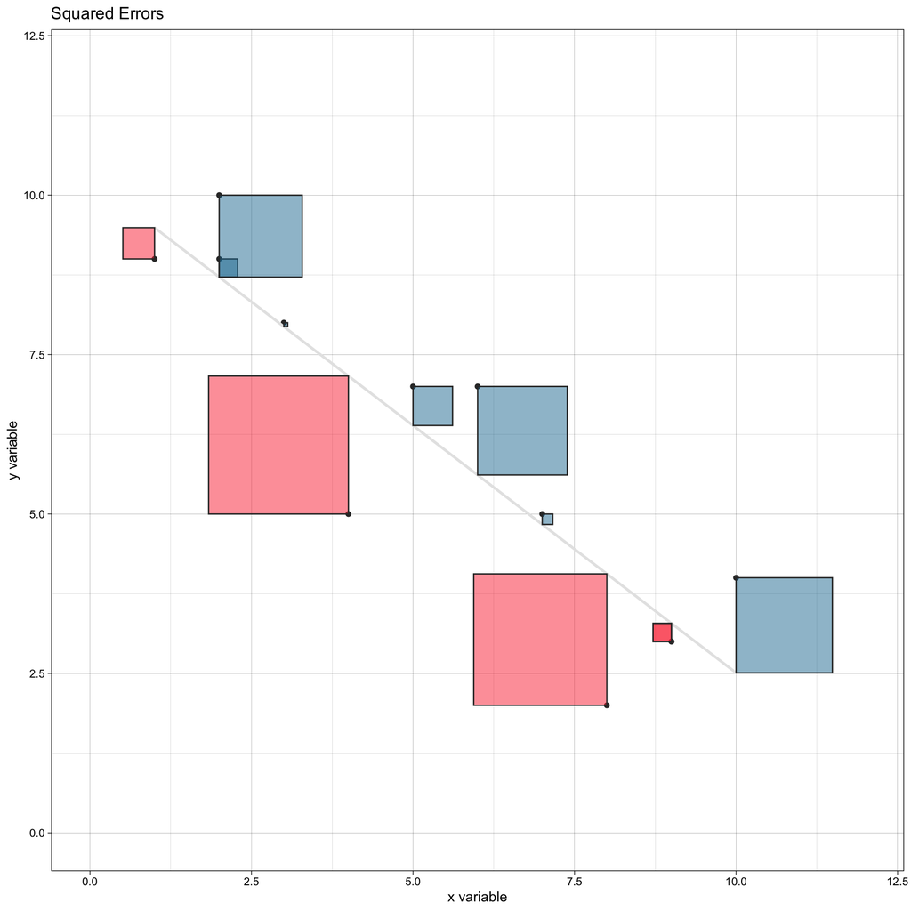

```r
#------------------------------------------------------------------------------
# errores cuadrados
#------------------------------------------------------------------------------

#----------------------------------------------------------
# crear valores esperados
#----------------------------------------------------------

fitted_values <- lm(y ~ + 1 + x, data = data_model) %>%
                 predict()

#----------------------------------------------------------
# agregar valores esperados (y_hat), a una base de datos
#----------------------------------------------------------

data_fitted <- data_model %>%
               mutate(y_hat = fitted_values) %>%
               mutate(res = y - y_hat) %>%
               mutate(res_colour = case_when(
                res == 0 ~ 'grey80',
                res > 0 ~ '#247BA0', # red
                res < 0 ~ '#FB3640'  # blue
                ))

rect_colour <- data_fitted$res_colour

#----------------------------------------------------------
# squared errors
#----------------------------------------------------------

data_fitted %>%
ggplot(., aes(y = y, x = x)) +
geom_point(alpha = 1, col = 'grey20') +
ylim(0,12) +
xlim(0,12) +
  geom_smooth(
    formula = y ~x,
    method = "lm",
    se = FALSE,
    colour = "grey90",
    alpha = .005
    ) +
geom_rect(
   aes(
   xmin=x,
   xmax=x+res,
   ymin=y-res,
   ymax=y
   ),
  colour = 'grey20',
  fill=rect_colour,
  alpha=0.5
  ) +
xlab('x variable') +
ylab('y variable') +
ggtitle('Squared Errors') +
theme_linedraw()
```

# Error por modelo

## Sumas de errores cuadrados

La suma de errores cuadrados consiste en la suma total de residuales de un modelo. En otras palabras, es la suma de todas las distancias cuadráticas entre los valores observados, y los valores esperados por un modelo.

$$\text{SSE} = \sum{(y_{i} - \hat{y}_{i}})^2$$

En Vik (2014) se emplea más de una formula para obtener las sumas de cuadrados, diferenciando entre el modelo nulo o modelo compacto, y el modelo aumentado. Por conveniencia, vamos a crear una función que nos permita obtener la suma de errores de cuadrados de cada modelo ajustado.

```r
#------------------------------------------------------------------------------
# errores cuadrados
#------------------------------------------------------------------------------

#----------------------------------------------------------
# función SSE
#----------------------------------------------------------

sse_model <- function(model){

y     <- model$model[,1]
y_hat <- model$fitted.values
squared_errors <- (y - y_hat)^2
sse <- sum(squared_errors)

return(sse)
}

#----------------------------------------------------------
# extraer SSE
#----------------------------------------------------------

sse_00 <- sse_model(m00)
sse_01 <- sse_model(m01)
sse_02 <- sse_model(m02)

#----------------------------------------------------------
# crear tabla
#----------------------------------------------------------

sse_table <- data.frame(
  model = c(
    'null model',
    'augmented model',
    'centered x model'
    ),
  see = c(sse_00, sse_01, sse_02)
  )

#----------------------------------------------------------
# mostrar tabla
#----------------------------------------------------------

knitr::kable(sse_table, digits = 2)
```

| model | see |
| --- | --- |
| null model | 80.00 |
| augmented model | 15.62 |
| centered x model | 15.62 |

## Descomponer Error total

El error total del modelo nulo (o modelo compacto), puede ser descompuesto en términos del error reducido (o explicado), y lo que nos queda (el residuo). Esta idea puede ser expresada de la siguiente forma:

$$\text{SST} = \text{SSR} + \text{SSE}_{\text{m01}}$$

$\text{SST}$ es el error total, que lo obtenemos del modelo compacto o modelo nulo. El error reducido $\text{SSR}$, o error explicado lo obtenemos como la resta entre el error total, menos el error residual del modelo aumentado (ver Vik, 2014, p24). Y finalmente, el error residual $\text{SSE}_{\text{m01}}$ son los errores cuadrados del modelo aumentado.

```r
#------------------------------------------------------------------------------
# des composicion de errores
#------------------------------------------------------------------------------

#----------------------------------------------------------
# obtener medidas de error
#----------------------------------------------------------

total_error <- sse_00
residual_error <- sse_01
explained_error <- total_error - residual_error


#----------------------------------------------------------
# crear tabla
#----------------------------------------------------------

error_table <- data.frame(
  error = c(
    'Total Error',
    'Residual Error',
    'Explained Error'
    ),
  value = c(
    total_error,
    residual_error,
    explained_error
    )
  )

#----------------------------------------------------------
# mostrar tabla
#----------------------------------------------------------

knitr::kable(error_table, digits = 2)
```

| error | value |
| --- | --- |
| Total Error | 80.00 |
| Residual Error | 15.62 |
| Explained Error | 64.38 |

```r
#----------------------------------------------------------
# proporcion de varianza explicada
#----------------------------------------------------------

# proporción de SSE sobre el total
explained_error/total_error
```

```
## [1] 0.8047897
```

```r
# R2 del modelo
summary(m01)$r.squared
```

```
## [1] 0.8047897
```

# Evaluación de suppuestos

- Vamos a re ajustar los modelos vistos
  - El modelo de medias, modelo nulo o modelo compacto (m00)
  - El modelo con una covariable, o modelo aumentado (m01)
  - El modelo anterior, pero reparametrizado con la covariable centrada a la gran media (m02)
- Luego, emplearemos el último moodelo para realizar diagnósticos sobre el modelo ajustado
  - Linealidad de la relacion entre variables
  - Homocedasticidad (varianzas homogenas de los residuales)
  - Normalidad de los residuales
  - Independencia de las observaciones

```r
#------------------------------------------------------------------------------
# regresiones empleadas
#------------------------------------------------------------------------------

#--------------------------------------
# formulas
#--------------------------------------

f00 <- as.formula(y ~ + 1)
f01 <- as.formula(y ~ + 1 + x)
f02 <- as.formula(y ~ + 1 + x_cgm)

#--------------------------------------
# ajustar modelos
#--------------------------------------

m00 <- lm(f00, data = data_model)
m01 <- lm(f01, data = data_model)
m02 <- lm(f02, data = data_model)

#--------------------------------------
# comparar modelos de forma sintética
#--------------------------------------

texreg::screenreg(
    list(m00, m01, m02),
    star.symbol = "*",
    center = TRUE,
    doctype = FALSE,
    dcolumn = TRUE,
    booktabs = TRUE,
    single.row = FALSE
    )
```

```
##
## ============================================
##              Model 1    Model 2    Model 3
## --------------------------------------------
## (Intercept)   6.00 ***  10.27 ***   6.00 ***
##              (0.78)     (0.76)     (0.36)
## x                       -0.78 ***
##                         (0.12)
## x_cgm                              -0.78 ***
##                                    (0.12)
## --------------------------------------------
## R^2           0.00       0.80       0.80
## Adj. R^2      0.00       0.79       0.79
## Num. obs.    12         12         12
## ============================================
## *** p < 0.001; ** p < 0.01; * p < 0.05
```

## Linealidad del modelo

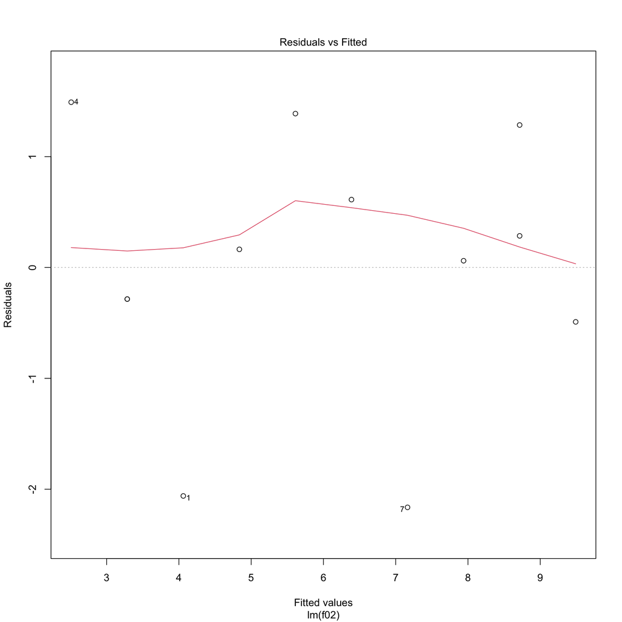

```r
#------------------------------------------------------------------------------
# diagnósticos
#------------------------------------------------------------------------------

#--------------------------------------
# residual vs fitted
#--------------------------------------

plot(m02, 1)
```

- Lo que esperamos, es que la dispersión de nuestros residuos sea homogenea al rededor de los datos ajustados.
- Esperamos, que nuestra linea central en este gráfico sea horizontal.

## Homocesdasticidad

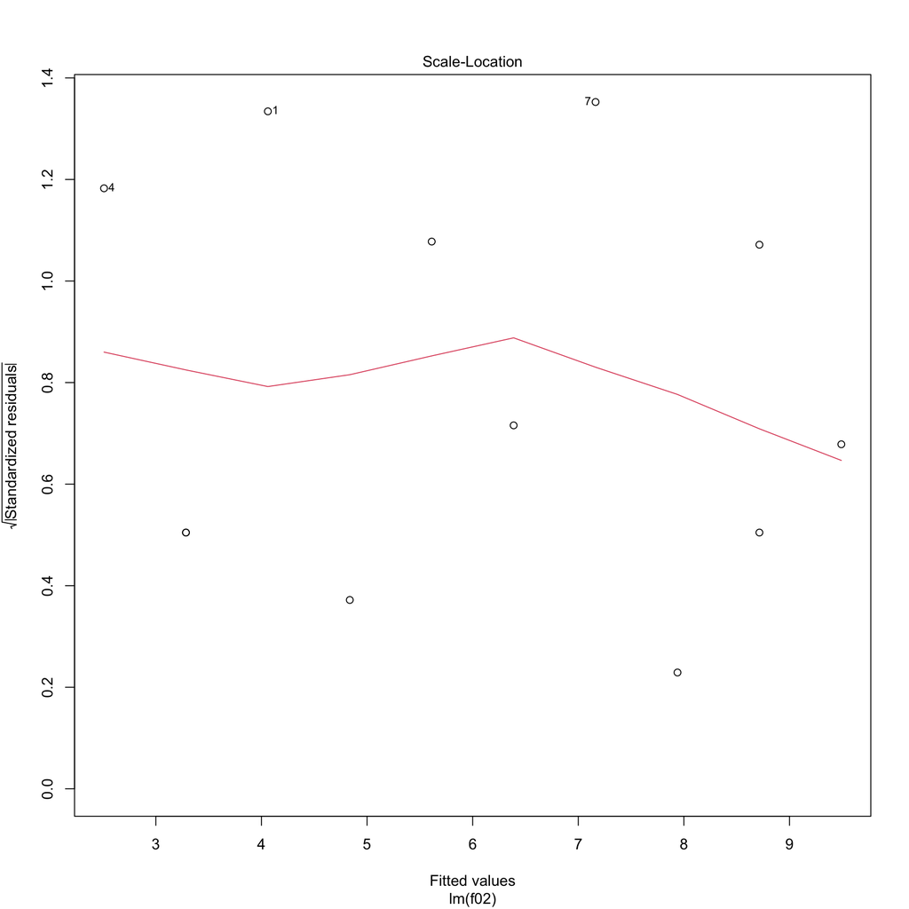

```r
#------------------------------------------------------------------------------
# diagnósticos
#------------------------------------------------------------------------------

#--------------------------------------
# homocedasticity
#--------------------------------------

plot(m02, 3)
```

```r
#--------------------------------------
# homocedasticity test
#--------------------------------------

# Breusch-Pagan test
lmtest::bptest(m02)
```

```
##
##  studentized Breusch-Pagan test
##
## data:  m02
## BP = 0.21984, df = 1, p-value = 0.6392
```

- La homocedasticidad refiere a que observemos varianzas similares de los errores del modelo (los residuales), a diferentes valores predichos
- Esperamos que, nuestros residuales tomen posiciones similares a lo largo de largo de los valores ajustados.
- La prueba Breusch-Pagan evalua si los residuales presentan varianza similar a todos los valores predichos, o si esta difiere (no hay varianza homogenea).
  - Los resultados de la aprueba no apoyan la hipotesis de que la varianza de los residuales fuera heterocedastica a los valores esperados por el modelo.

## Normalidad de los residuos

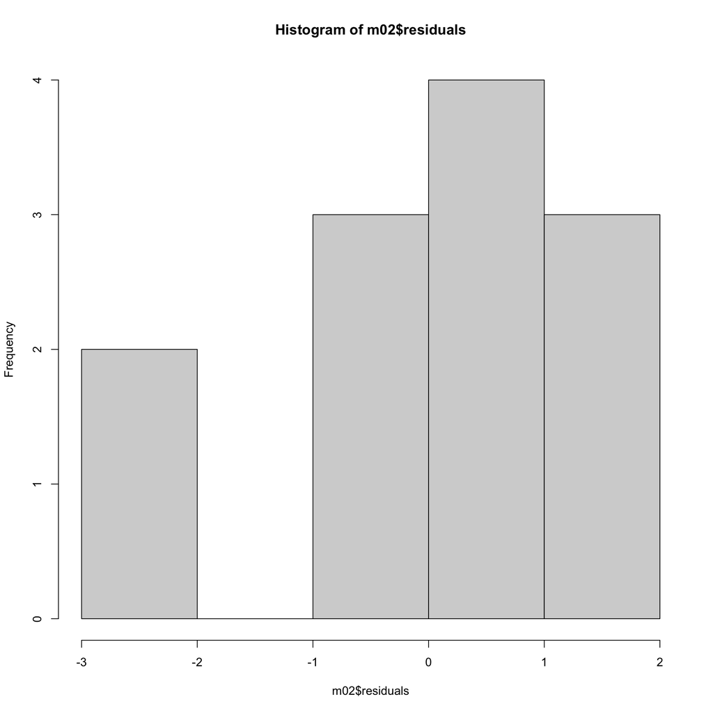

```r
#------------------------------------------------------------------------------
# diagnósticos
#------------------------------------------------------------------------------

#--------------------------------------
# histograma de residuos
#--------------------------------------

hist(m02$residuals)
```

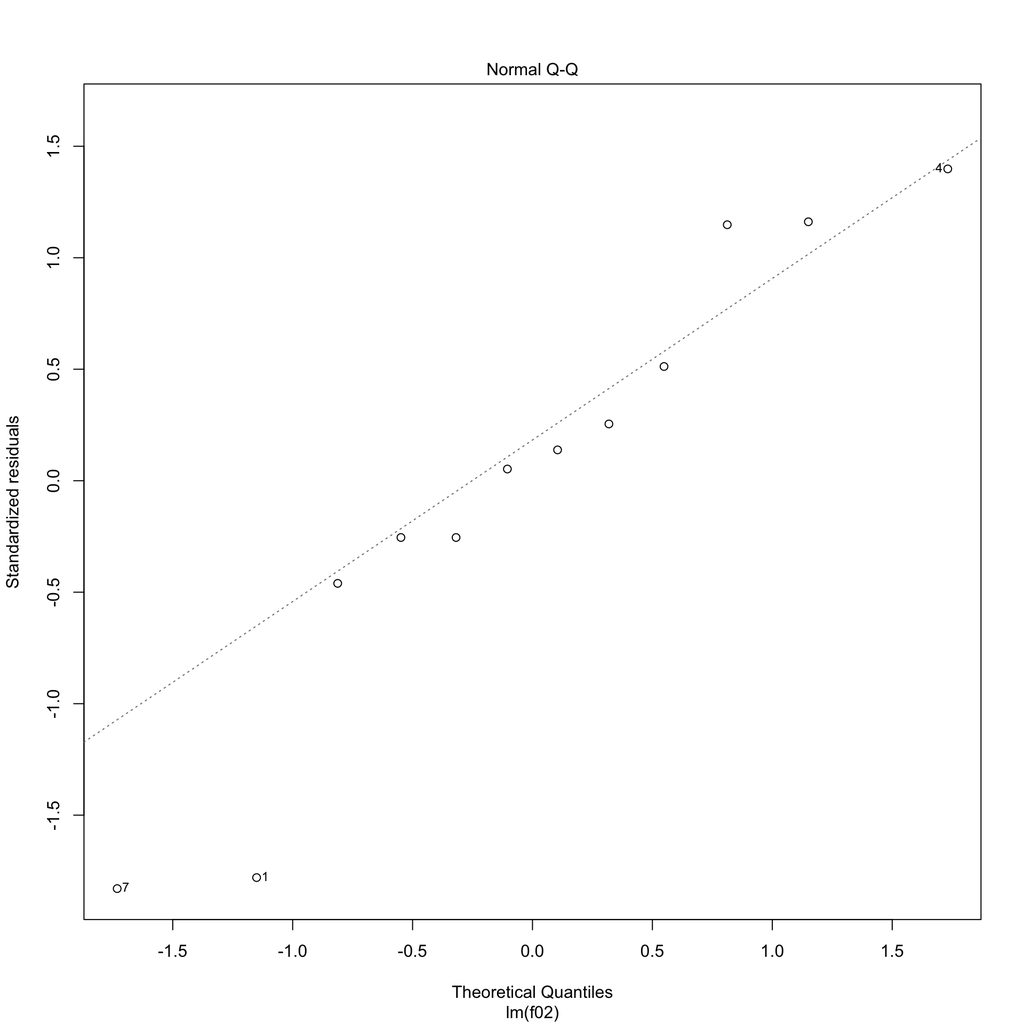

```r
#--------------------------------------
# normalidad de los residuos
#--------------------------------------

plot(m02, 2)
```

```r
#--------------------------------------
# Komogorov Smirnoff test
#--------------------------------------

ks.test(m02$residuals,
  "pnorm",
  mean=mean(m02$residuals),
  sd=sd(m02$residuals)
  )
```

```
##
##  One-sample Kolmogorov-Smirnov test
##
## data:  m02$residuals
## D = 0.17358, p-value = 0.8045
## alternative hypothesis: two-sided
```

- Uno modelo que ajusta bien a los datos, debiera presentar residuales que presenten una distribución normal.
- Los QQ plots, ordenan a los residuos en una diagonal, de tal forma que si estos se “desalinean” podemos sospechar que el supuesto de normalidad de los errores no se cumple.
- Podemos emplear el test Kolmogorov Smirnoff, y evaluar si la distribucion de errores discrepa de una distribución normal.
  - En este caso, los resultados de la prueba aplicada indican que nuestros datos no discrepan de la distribución esperada.

## Independencia de los errores

```r
#------------------------------------------------------------------------------
# diagnósticos
#------------------------------------------------------------------------------

#--------------------------------------
# independencia de los errores
#--------------------------------------

lmtest::dwtest(m02, alternative = 'two.sided')
```

[output not shown]

```r
#------------------------------------------------------------------------------
# diagnósticos
#------------------------------------------------------------------------------

#--------------------------------------
# caso de observaciones anidadas
#--------------------------------------

data_nested <- readRDS('nld_16.rds')

# Nota: datos de Holanda de ICCS 2016,
#       estudiantes de 8vo grado,
#       puntajes de conocimiento cívico (civ),
#       nivel socioeconómico (ses),
#       anidados en escuelas (id_j).
#       Correlación intraclase de civ, es
#       ICC = .55

#--------------------------------------
# Durbin Watson test no favorable
#--------------------------------------

lm(civ ~ ses, data = data_nested) %>%
lmtest::dwtest(.)

# Nota: cuando se ignora a las escuelas en el modelo,
#       el factor de anidación, encontramos evidencias
#       de que los residuales no son independientes entre sí.

#--------------------------------------
# Durbin Watson test favorable
#--------------------------------------

lm(civ ~ ses + as.factor(id_j), data = data_nested) %>%
lmtest::dwtest(.)

# Nota: se cumple el supuesto de independencia,
#       en caso de que se sature la varianza entre
#       escuelas.
```

[output not shown]